# RSTPYLabSetup

## Setup the Environment to Run Python scripts

To be installed from the `RSTPYLabSetup.html` file:

- Install Python3.9 CentOS Package
- Clone the Git Repo for the class
- Set up the Virtual Environment for Python using Python 3.9

To be installed from `Module0.ipynb` Jupyter Notebook from within the lab environment...  
The `Module0 Notebook` will be available after the git repo is cloned to your lab.

- Install the Required Packages in this environment
- Install the Netapp Ontap Python Client Library
- Install nbconvert to export Jupyter Notebooks to HTML

### Steps to be Completed from `RSTPYLabSetup.html`:

In the VS Code Window connected to the Linux `centos1`, open a Terminal Window using `` CTRL+` ``. If you would like to make the Terminal Window open in a Tab of it's own, click on the `bash ..` button at the top right of the terminal window that just opened.

[figure not shown]

Then Click on `Move Terminal to Editor Area` to open the terminal in a new Tab.

At the bash prompt, run the following command to install the most recent version of Python available in the CentOS 8.5 distribution which is Python3.9

```
yum install python39 -y
```

- Ignore any error messages regarding invalid configuration values such as :  
  "Invalid configuration value: failovermethod=priority in /etc/yum.repos.d/epel.repo; Configuration: OptionBinding with id "failovermethod" does not exist"

Once python3.9 is installed, we will have 3 different version of Python installed on our system.

#### Be Careful not to use Python 3.6 or 3.11. Use `Python3.9` instead.

- The Python 3.6 is not supported by the current version of the Python Debugger Extension in VS Code, that requires python greater than 3.8.
- The Python 3.11 installed on the system has not been compiled with sqlite3 support, which is required by the Jupyter Notebook extension we are going to use in class, to run correctly.

### Clone the Git Repo for the class.

In the VS Code window remotely connected to the Linux `centos1` host, Click on the `Explorer` Icon in the `Activity Bar`. Then Click on `Clone Repository`, to clone the files we will need in the labs.

[figure not shown]

In the `Clone from Github` dialog box,

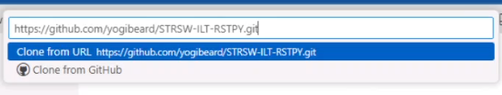

Enter the following Repository:

`https://github.com/yogibeard/STRSW-ILT-RSTPY.git`

In the `Choose a folder to clone ..` dialog, Select the default location `/root/` and Click on the `OK` button.

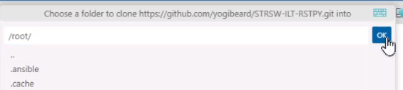

In the `Would you like to open the cloned repository` dialog, Click the `Open` button:

[figure not shown]

In the `Do you trust the Authors...` dialog box, Check the `Trust the authors...` check box, then Click on the `Yes, I trust the authors` button.

[figure not shown]

In the `Explorer` pane, Expand `Notebooks`, and open `Module0.ipynb` Jupyter Notebook.

Then Click on the `Select Kernel` to select in the top right of the window:

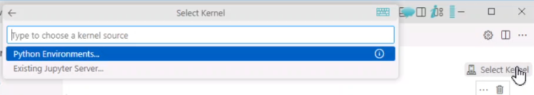

Click on the `Python Environments`, then Select `+ Create Python Environment`

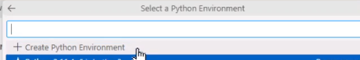

In the `Select an environment type` dialog, `Venv`

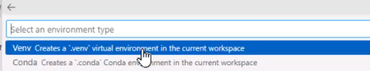

In the `Select Python Installation` dialog, Select Python 3.9 in `/usr/bin/python3.9`

After installing a few required packages in a short while, the environment will be ready.

You are now ready to continue the setup by running the remaining steps from the Module0 Jupyter Notebook in your lab.

**NB: In all the Jupyter Notebooks in the lab, if prompted to `select the kernel`, please select the Virtual Environment that we have just setup (`.venv(Python 3.9.6)`)**